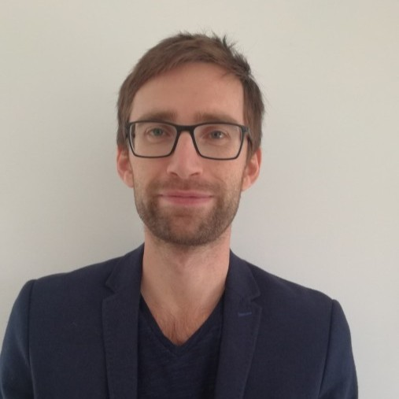

# Anthony Devaux, PhD

## Bio

Hi! My name is Anthony Devaux, I’m currently working as a Biostatistician at the George Institute for Global Health in Sydney, AUSTRALIA. Previously, I graduated my PhD in Biostatistics at the University of Bordeaux, FRANCE. My PhD topic was “Dynamic modelling and prediction of health events from multivariate longitudinal data”.

## Work experiences

- **Biostatistician** | March 2023 - Present | *The George Institute for Global Health* | Sydney, AUSTRALIA
- **PhD candidate** | September 2019 - December 2022 | *Bordeaux Population Health, Inserm U1219* | Bordeaux, FRANCE
- **Admission office manager** | January 2013 - August 2017 | *Moulins-Yzeure Hospital* | Moulins, FRANCE
- **Statistician** | September 2010 - December 2012 | *Laboratoire National de Santé* | Luxembourg, LUXEMBOURG

## Education

- **PhD in Biostatistics** | September 2019 - December 2022 | *Bordeaux Population Health, Inserm U1219* | Bordeaux, FRANCE
- **Master in Public Health, option Biostatistics** | September 2018 - June 2019 | *ISPED School of public health* | Bordeaux, FRANCE
- **Bachelor in Statistics, option Application to life sciences** | September 2009 - June 2010 | *University of Lorraine* | Metz, FRANCE

## Publications

- **Devaux, A.**, Proust-Lima, C. and Genuer, R. (2022). Random Forests for time-fixed and time-dependent predictors: The DynForest R package. *arXiv*. doi: https://doi.org/10.48550/arXiv.2302.02670
- **Devaux, A.**, Helmer, C., Genuer, R., and Proust-Lima, C. (2022). Random survival forests with multivariate longitudinal endogenous covariates. *arXiv*. doi: https://doi.org/10.48550/arXiv.2208.05801
- **Devaux, A.**, Genuer, R., Peres, K., and Proust-Lima, C. (2022). Individual dynamic prediction of clinical endpoint from large dimensional longitudinal biomarker history: a landmark approach. *BMC Medical Research Methodology*, 22(1): 1–14. doi: https://doi.org/10.1186/s12874-022-01660-3
- Mossong, J., Mughini-Gras, L., Penny, C., **Devaux, A.**, Olinger, C., Losch, S., Cauchie, H.M., Van Pelt, W. and Ragimbeau, C. (2016). Human Campylobacteriosis in Luxembourg, 2010–2013: A Case-Control Study Combined with Multilocus Sequence Typing for Source Attribution and Risk Factor Analysis. *Scientific Reports*, 6(1): 1-12. doi: https://doi.org/10.1038/srep20939
- Ragimbeau, C., Colin, S., **Devaux, A.**, Decruyenaere, F., Cauchie, H.M., Losch, S., Penny, C. and Mossong, J. (2014). Investigating the host specificity of Campylobacter jejuni and Campylobacter coli by sequencing gyrase subunit A. *BMC microbiology*, 14(1): 1-12. doi: https://doi.org/10.1186/s12866-014-0205-7
- Mossong, J., Gelhausen, E., Decruyenaere, F., **Devaux, A.**, Perrin, M., Even, J. and Heisbourg E. (2013). Prevalence, risk factors and molecular epidemiology of methicillin-resistant Staphylococcus aureus (MRSA) colonization in residents of long-term care facilities in Luxembourg, 2010. *Epidemiology & Infection*, 141(6): 1199-1205. doi: https://doi.org/10.1017/S0950268812001999

## Packages

- **DynForest**: Random Forest with Multivariate Longitudinal Predictors. R package version: 1.1.1. https://CRAN.R-project.org/package=DynForest
- **hdlandmark**: Dynamic Predictions with Multivariate Longitudinal Predictors by Landmark Approach. GitHub development version. https://github.com/anthonydevaux/hdlandmark